# Teacher Engagement Report

## Job Satisfaction Factors

### Levels of Satisfaction Associated with the Job

This set of items evaluate the extent to which teachers are satisfied with different aspects of their jobs.

Environment Factors

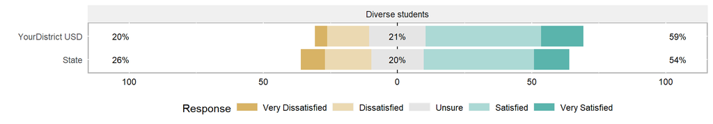

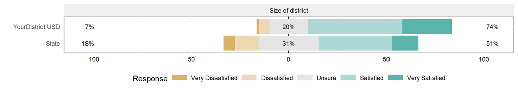

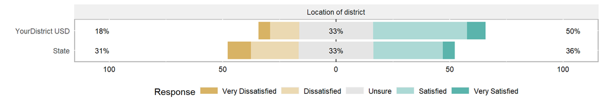

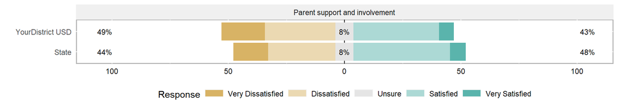

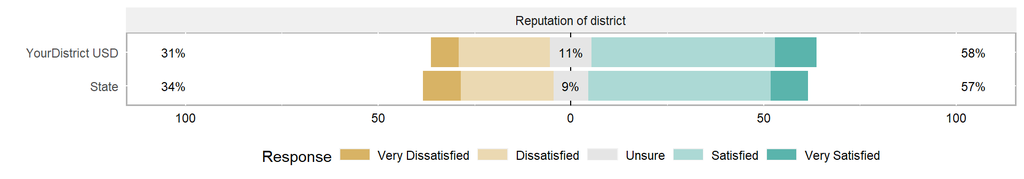

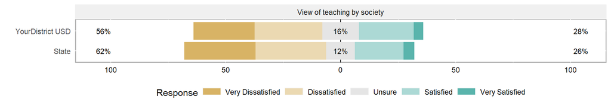

Resource Factors

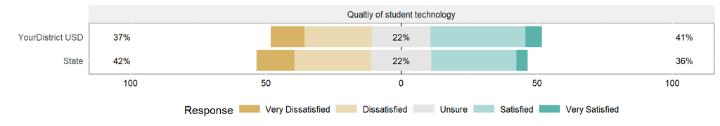

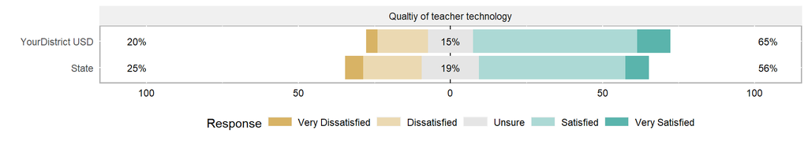

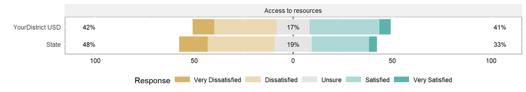

Instructional Factors

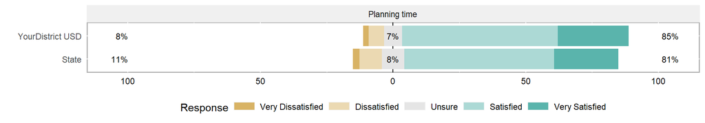

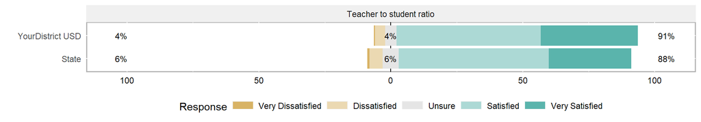

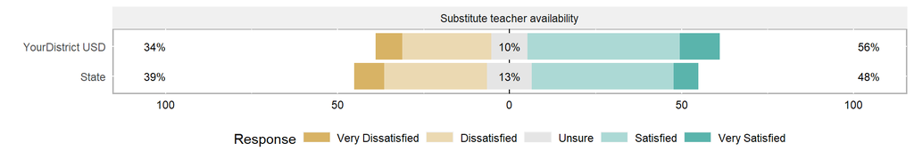

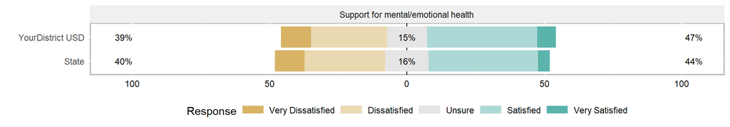

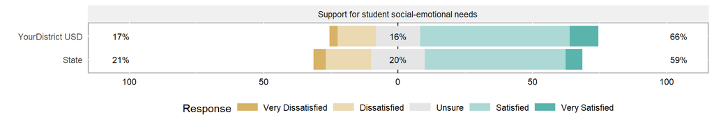

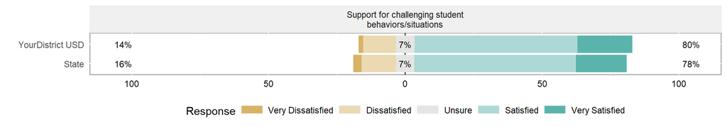

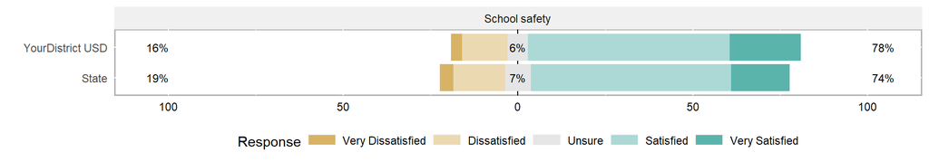

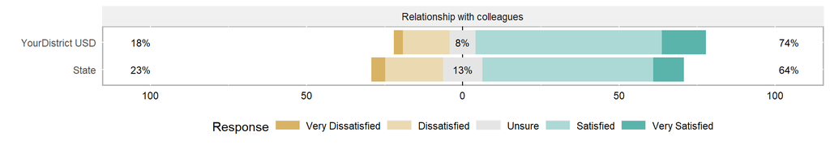

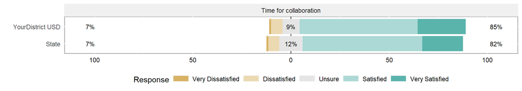

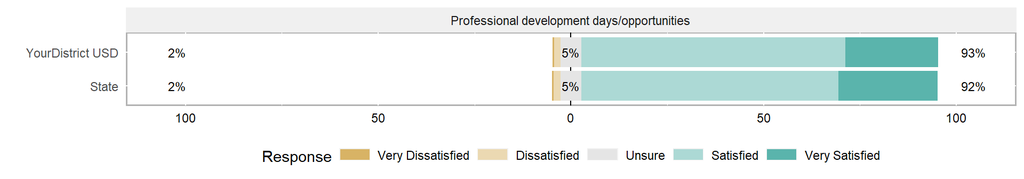

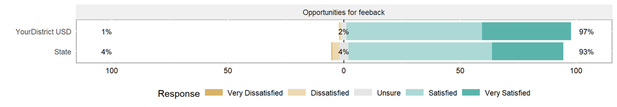

Relationship Factors

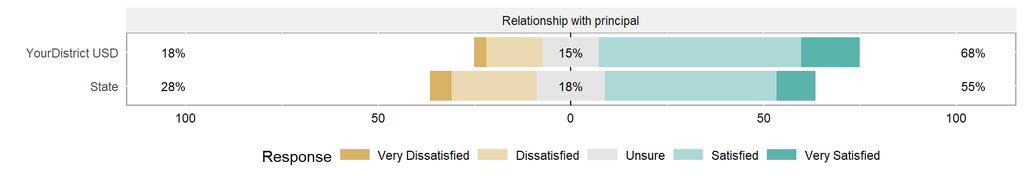

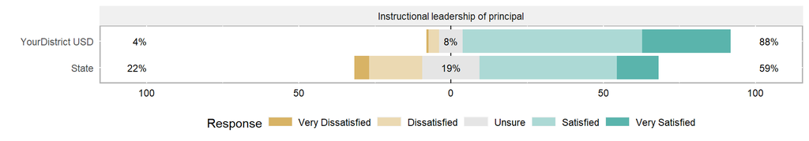

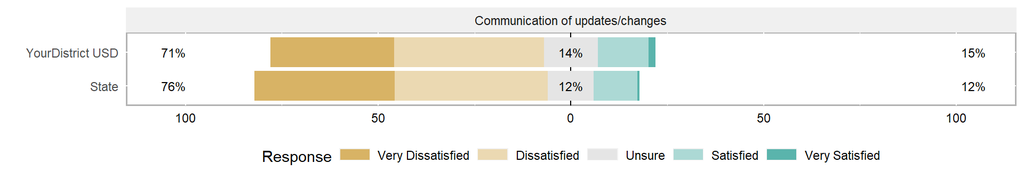

Support Factors

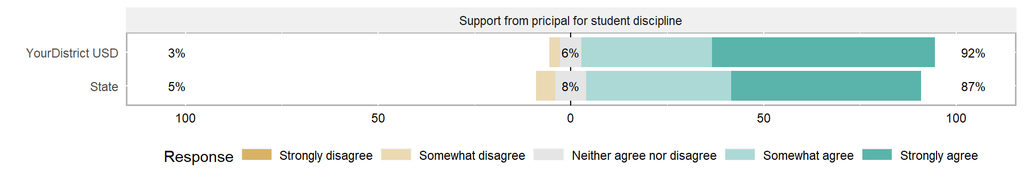

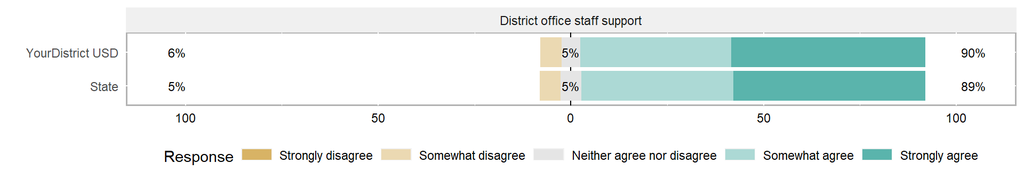

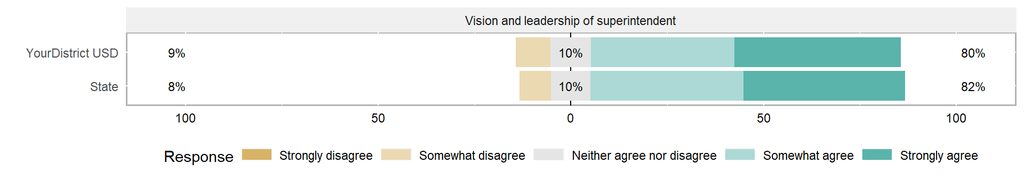

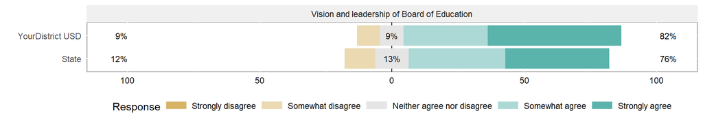

Professional Factors

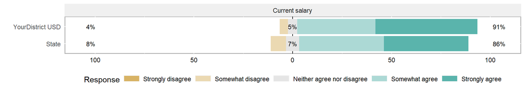

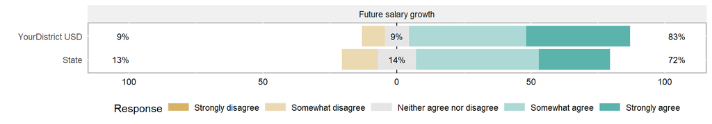

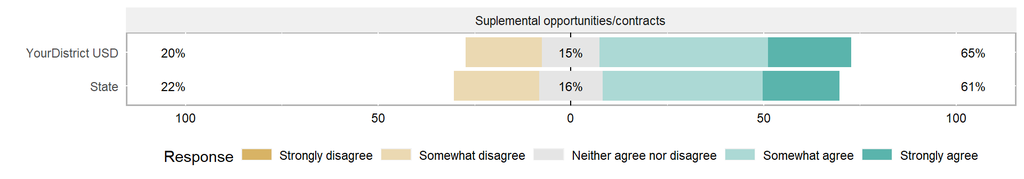

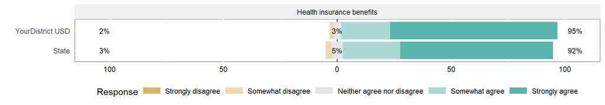

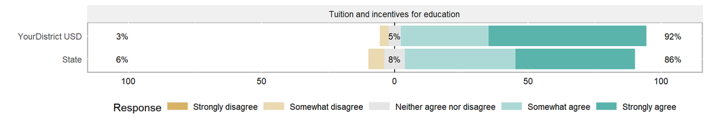

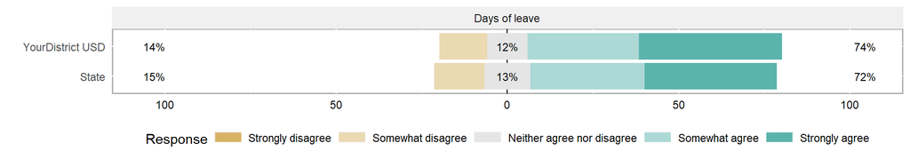

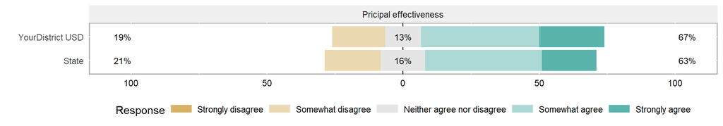

## Retention Factors

### Areas That Impact Decisions to Stay

Leaving/Retention

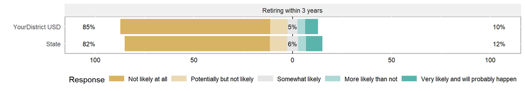

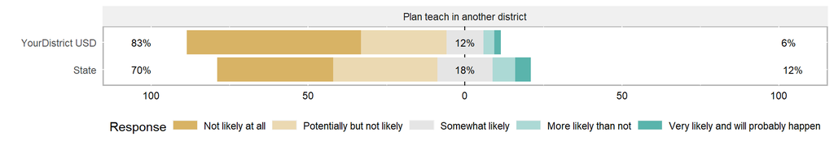

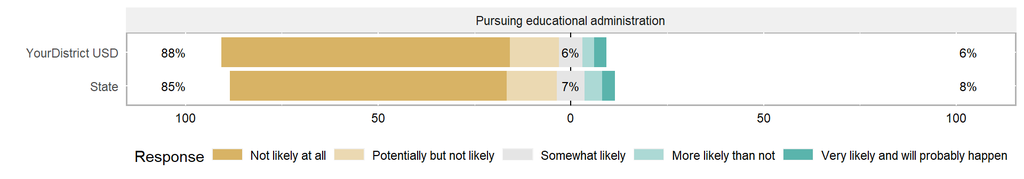

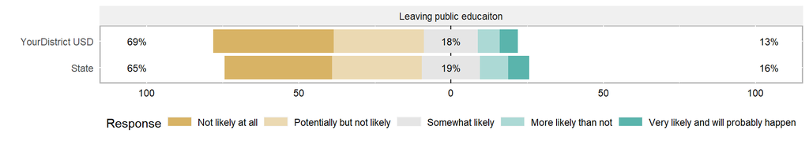

# Teacher Retention Study Overview

Data was collected across 273 school districts in Kansas to understand the key factors that drive teacher retention. Starting the Summer of 2021, this project has been funded by the KASB, KBA, and Emporia State University. There is the potential to perform more in-depth analyses and support but please contact Dr. Bret Church or Dr. Luke Simmering if you’d like to discuss options. Options include custom benchmarks to compare to similar districts (i.e., location, size, etc.) as well as more inferential analysis to predict which factors are the most significant drivers of retention and engagement. Advisory support is also available to collaboratively develop goals and action plans to engage and retain teachers within your particular district. Survey metrics can be used to track engagement and/or retention over time in order to provide evidence regarding interventions.

# Interpretation Guidance

Items were evaluated on a 5-point Likert scale to assess the extent to which they aligned with the presented area and/or aspect of teaching.

To learn more about this data and to uncover additional analysis and insights, please contact:

Dr. Bret Church

Dr. Luke Simmering